# Assignment 7

Michelle

4/28/2020

#First get packages we need

```r
install.packages("yearn")
install.packages("OUwie")
install.packages("nloptr")
install.packages("lattice")
install.packages("phytools")
```

```r
library(ape)
library(geiger)
library(OUwie)
library(nloptr)
library(lattice)
library (corHMM)
library(phangorn)
library(openxlsx)
library(rotl)
library(phytools)
```

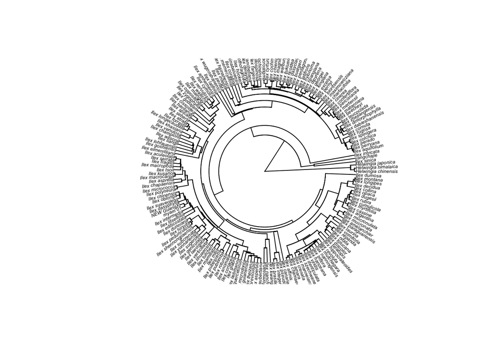

```r
hollies <- get_study_tree("ot_1984", "tree1")
hollies.study.metadat<-get_study_meta("ot_1984")
hollies.tree.ids<-get_tree_ids(hollies.study.metadat)
plot(hollies, type="fan", cex = 0.4)
```

#Now get the tree and data. For these exercises, knowing uncertainty in your measurements can also be important. #(remember for homework to change eval=FALSE to eval=TRUE).

```r
hollies <- get_study_tree("ot_1984", "tree1")
print (hollies)
```

```
##
## Phylogenetic tree with 175 tips and 174 internal nodes.
##
## Tip labels:
##  Helwingia_chinensis, Helwingia_himalaica, Helwingia_japonica, Ilex_sinica, yangchajie, Ilex_intricata, ...
##
## Rooted; includes branch lengths.
```

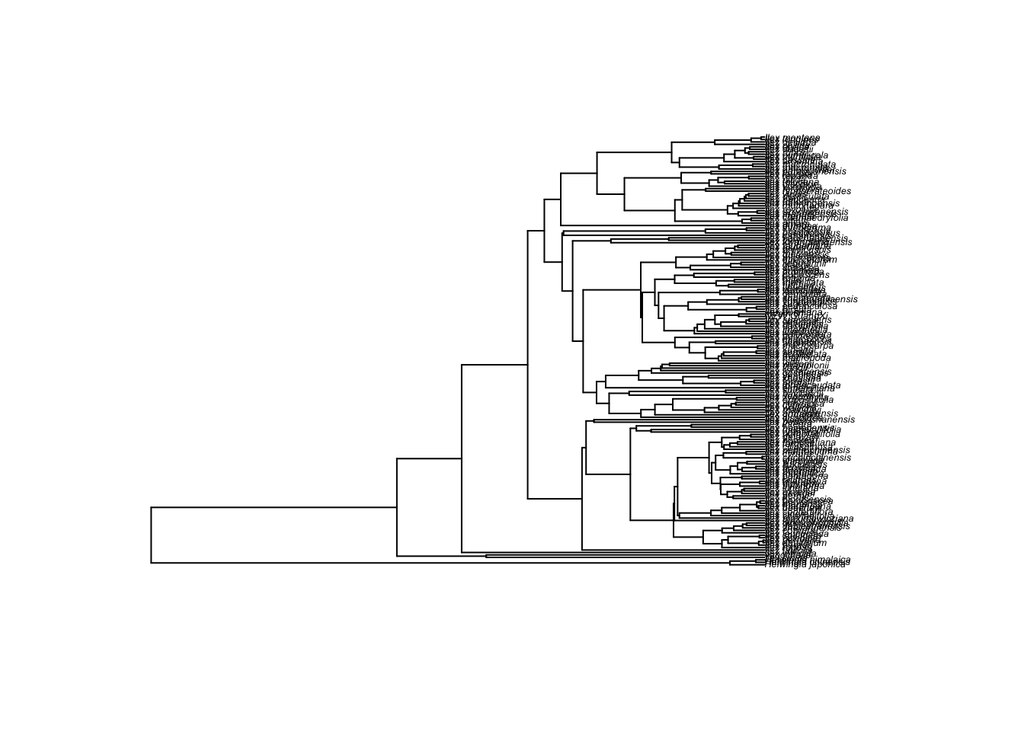

```r
hollies.study.metadat<-get_study_meta("ot_1984")
hollies.tree.ids<-get_tree_ids(hollies.study.metadat)
plot(hollies, cex = 0.4)
```

```r
setwd("~/phylometh_exercises-/data\ set\ 6\ and\ 7")

hollies.data <- read.xlsx (xlsxFile = "hollies.xlsx", startRow = 2)
head(hollies.data )
```

```
##                                  species colour fruit.diameter.(mm)  margin
## 1                  Ilex aculeolata Nakai  black                 7.0 serrate
## 2                   Ilex affinis Gardner  black                 4.0 serrate
## 3                       Ilex amara Loes.    red                 5.5 serrate
## 4 Ilex amelanchier M.A. Curtis ex Chapm.    red                 7.5  entire
## 5              Ilex anomala Hook. & Arn.  black                 9.0  entire
## 6                     Ilex aquifolium L.    red                 8.0   spiny
##   maximum.height.(m)
## 1                  4
## 2                  6
## 3                  4
## 4                  2
## 5                  9
## 6                 25
```

```r
#Take the first 2 names and anytime there is an "_" it will split and put it together.
GetGenusSpeciesOneTaxon <- function(x) {
  x <- gsub("_", " ", x)
  x <- strsplit(x, "\\s+")[[1]]
  return(paste0(x[1:2], collapse="_"))
}
GetGenusSpeciesManyTaxa <- function(x) {
  return(unname(sapply(x, GetGenusSpeciesOneTaxon)))
}
# To get ride of the space and replace it with an "_"
hollies.data$species <- GetGenusSpeciesManyTaxa(gsub(" ", "_", hollies.data$species))

head(hollies.data )
```

```
##            species colour fruit.diameter.(mm)  margin maximum.height.(m)
## 1  Ilex_aculeolata  black                 7.0 serrate                  4
## 2     Ilex_affinis  black                 4.0 serrate                  6
## 3       Ilex_amara    red                 5.5 serrate                  4
## 4 Ilex_amelanchier    red                 7.5  entire                  2
## 5     Ilex_anomala  black                 9.0  entire                  9
## 6  Ilex_aquifolium    red                 8.0   spiny                 25
```

```r
#To read csv files
#discrete.data <- read.csv(file= "hollies.xlsx", stringsAsFactors=FALSE)
```

```r
#To get the fruit.diameter.(mm) data
#hollies.traits <- hollies.data[,c("species", "fruit.diameter", "colour")]
#print(head(hollies.traits))
print(colnames(hollies.data))
```

```
## [1] "species"             "colour"              "fruit.diameter.(mm)"
## [4] "margin"              "maximum.height.(m)"
```

```r
hollies.fruit.diameter <- hollies.data$fruit.diameter
names(hollies.fruit.diameter) <- hollies.data$species
print(head(hollies.fruit.diameter))
```

```
##  Ilex_aculeolata     Ilex_affinis       Ilex_amara Ilex_amelanchier
##              7.0              4.0              5.5              7.5
##     Ilex_anomala  Ilex_aquifolium
##              9.0              8.0
```

```r
print(hollies.fruit.diameter)
```

```
##       Ilex_aculeolata          Ilex_affinis            Ilex_amara
##                  7.00                  4.00                  5.50
##      Ilex_amelanchier          Ilex_anomala       Ilex_aquifolium
##                  7.50                  9.00                  8.00
##        Ilex_argentina      Ilex_arnhemensis         Ilex_asperula
##                  6.50                  4.50                  4.00
##         Ilex_asprella           Ilex_atrata         Ilex_beecheyi
##                  6.00                  6.50                 10.00
##     Ilex_bioritsensis     Ilex_brasiliensis      Ilex_brevicuspis
##                  7.00                  5.50                  3.75
##         Ilex_buergeri      Ilex_canariensis          Ilex_cassine
##                  5.25                 10.00                  5.50
##  Ilex_centrochinensis   Ilex_chamaedryfolia       Ilex_championii
##                  6.50                  3.50                  3.50
##       Ilex_chapaensis    Ilex_chartacifolia        Ilex_chieniana
##                 17.50                  6.00                 10.00
##        Ilex_chinensis     Ilex_ciliospinosa          Ilex_cinerea
##                  7.00                  5.50                  7.00
##        Ilex_cissoidea  Ilex_cochinchinensis         Ilex_colchica
##                  3.00                  6.00                 10.00
##          Ilex_collina    Ilex_confertiflora        Ilex_corallina
##                  7.50                  5.00                  3.50
##         Ilex_coriacea          Ilex_cornuta          Ilex_crenata
##                  8.00                  9.00                  7.00
##       Ilex_cumulicola           Ilex_cymosa          Ilex_cyrtura
##                  9.00                  3.00                  6.00
##   Ilex_dabieshanensis        Ilex_dasyclada       Ilex_dasyphylla
##                  4.50                  3.50                  6.00
##          Ilex_decidua         Ilex_delavayi      Ilex_denticulata
##                  6.50                  5.00                  6.50
##   Ilex_dimorphophylla         Ilex_dipyrena         Ilex_discolor
##                  6.00                  8.00                  5.00
##          Ilex_dugesii           Ilex_dumosa         Ilex_dunniana
##                  8.00                  6.00                  5.00
##     Ilex_editicostata    Ilex_elmerrilliana          Ilex_excelsa
##                  8.00                  5.00                  4.25
##         Ilex_fargesii         Ilex_ficoidea        Ilex_formosana
##                  6.00                  6.00                  5.00
##        Ilex_forrestii         Ilex_fragilis     Ilex_franchetiana
##                  4.00                  5.00                  6.50
```

[output cut: 59 more lines]

```
##                  2.00                  7.50                  7.50
##      Ilex_taubertiana        Ilex_teratopis         Ilex_theizans
##                  3.25                  7.00                  7.00
##         Ilex_tolucana         Ilex_triflora       Ilex_tsiangiana
##                  7.00                  6.50                  3.50
##             Ilex_tsoi         Ilex_tutcheri         Ilex_venulosa
##                  7.00                  5.00                  4.00
##     Ilex_verticillata          Ilex_viridis        Ilex_vomitoria
##                  7.00                 10.00                  6.35
##        Ilex_warburgii        Ilex_wallichii         Ilex_wilsonii
##                 10.00                  5.50                  4.00
##   Ilex_wugonshanensis      Ilex_yunnanensis    Ilex_zhejiangensis
##                  6.50                  5.50                  7.50
##       Ilex_zygophylla
##                  4.00
```

```r
hollies.colour <- hollies.data$colour
names(hollies.colour) <- hollies.data$species
print(head(hollies.colour))
```

```
##  Ilex_aculeolata     Ilex_affinis       Ilex_amara Ilex_amelanchier
##          "black"          "black"            "red"            "red"
##     Ilex_anomala  Ilex_aquifolium
##          "black"            "red"
```

```r
print(hollies.colour)
```

```
##       Ilex_aculeolata          Ilex_affinis            Ilex_amara
##               "black"               "black"                 "red"
##      Ilex_amelanchier          Ilex_anomala       Ilex_aquifolium
##                 "red"               "black"                 "red"
##        Ilex_argentina      Ilex_arnhemensis         Ilex_asperula
##                  "na"               "brown"                  "na"
##         Ilex_asprella           Ilex_atrata         Ilex_beecheyi
##               "black"                 "red"                  "na"
##     Ilex_bioritsensis     Ilex_brasiliensis      Ilex_brevicuspis
##                 "red"               "black"               "black"
##         Ilex_buergeri      Ilex_canariensis          Ilex_cassine
##                 "red"                 "red"                 "red"
##  Ilex_centrochinensis   Ilex_chamaedryfolia       Ilex_championii
##                 "red"               "black"                 "red"
##       Ilex_chapaensis    Ilex_chartacifolia        Ilex_chieniana
##               "black"                 "red"                 "red"
##        Ilex_chinensis     Ilex_ciliospinosa          Ilex_cinerea
##                 "red"                 "red"                 "red"
##        Ilex_cissoidea  Ilex_cochinchinensis         Ilex_colchica
##                  "na"                 "red"                 "red"
##          Ilex_collina    Ilex_confertiflora        Ilex_corallina
##                 "red"                  "na"                 "red"
##         Ilex_coriacea          Ilex_cornuta          Ilex_crenata
##               "black"                 "red"               "black"
##       Ilex_cumulicola           Ilex_cymosa          Ilex_cyrtura
##                 "red"                 "red"                 "red"
##   Ilex_dabieshanensis        Ilex_dasyclada       Ilex_dasyphylla
##                 "red"                 "red"                 "red"
##          Ilex_decidua         Ilex_delavayi      Ilex_denticulata
##               "black"                 "red"               "black"
##   Ilex_dimorphophylla         Ilex_dipyrena         Ilex_discolor
##                 "red"                 "red"                  "na"
##          Ilex_dugesii           Ilex_dumosa         Ilex_dunniana
##                 "red"               "black"                 "red"
##     Ilex_editicostata    Ilex_elmerrilliana          Ilex_excelsa
##                 "red"                 "red"                 "red"
##         Ilex_fargesii         Ilex_ficoidea        Ilex_formosana
##                 "red"                 "red"                 "red"
##        Ilex_forrestii         Ilex_fragilis     Ilex_franchetiana
##                 "red"                 "red"                 "red"
```

[output cut: 59 more lines]

```
##                 "red"                 "red"               "black"
##      Ilex_taubertiana        Ilex_teratopis         Ilex_theizans
##               "brown"               "black"                 "red"
##         Ilex_tolucana         Ilex_triflora       Ilex_tsiangiana
##                 "red"               "black"                 "red"
##             Ilex_tsoi         Ilex_tutcheri         Ilex_venulosa
##               "black"                 "red"                 "red"
##     Ilex_verticillata          Ilex_viridis        Ilex_vomitoria
##                 "red"               "black"                 "red"
##        Ilex_warburgii        Ilex_wallichii         Ilex_wilsonii
##                 "red"                  "na"                 "red"
##   Ilex_wugonshanensis      Ilex_yunnanensis    Ilex_zhejiangensis
##                 "red"                 "red"                 "red"
##       Ilex_zygophylla
##                 "red"
```

```r
hollies.colour <- hollies.colour[!grepl("na", hollies.colour)]
print(hollies.colour)
```

```
##       Ilex_aculeolata          Ilex_affinis            Ilex_amara
##               "black"               "black"                 "red"
##      Ilex_amelanchier          Ilex_anomala       Ilex_aquifolium
##                 "red"               "black"                 "red"
##      Ilex_arnhemensis         Ilex_asprella           Ilex_atrata
##               "brown"               "black"                 "red"
##     Ilex_bioritsensis     Ilex_brasiliensis      Ilex_brevicuspis
##                 "red"               "black"               "black"
##         Ilex_buergeri      Ilex_canariensis          Ilex_cassine
##                 "red"                 "red"                 "red"
##  Ilex_centrochinensis   Ilex_chamaedryfolia       Ilex_championii
##                 "red"               "black"                 "red"
##       Ilex_chapaensis    Ilex_chartacifolia        Ilex_chieniana
##               "black"                 "red"                 "red"
##        Ilex_chinensis     Ilex_ciliospinosa          Ilex_cinerea
##                 "red"                 "red"                 "red"
##  Ilex_cochinchinensis         Ilex_colchica          Ilex_collina
##                 "red"                 "red"                 "red"
##        Ilex_corallina         Ilex_coriacea          Ilex_cornuta
##                 "red"               "black"                 "red"
##          Ilex_crenata       Ilex_cumulicola           Ilex_cymosa
##               "black"                 "red"                 "red"
##          Ilex_cyrtura   Ilex_dabieshanensis        Ilex_dasyclada
##                 "red"                 "red"                 "red"
##       Ilex_dasyphylla          Ilex_decidua         Ilex_delavayi
##                 "red"               "black"                 "red"
##      Ilex_denticulata   Ilex_dimorphophylla         Ilex_dipyrena
##               "black"                 "red"                 "red"
##          Ilex_dugesii           Ilex_dumosa         Ilex_dunniana
##                 "red"               "black"                 "red"
##     Ilex_editicostata    Ilex_elmerrilliana          Ilex_excelsa
##                 "red"                 "red"                 "red"
##         Ilex_fargesii         Ilex_ficoidea        Ilex_formosana
##                 "red"                 "red"                 "red"
##        Ilex_forrestii         Ilex_fragilis     Ilex_franchetiana
##                 "red"                 "red"                 "red"
##          Ilex_georgei           Ilex_glabra          Ilex_godajam
##                 "red"               "black"                 "red"
##       Ilex_goshiensis       Ilex_guianensis         Ilex_hanceana
##                 "red"               "black"                 "red"
```

[output cut: 39 more lines]

```
##                 "red"                 "red"                 "red"
##    Ilex_szechwanensis      Ilex_taubertiana        Ilex_teratopis
##               "black"               "brown"               "black"
##         Ilex_theizans         Ilex_tolucana         Ilex_triflora
##                 "red"                 "red"               "black"
##       Ilex_tsiangiana             Ilex_tsoi         Ilex_tutcheri
##                 "red"               "black"                 "red"
##         Ilex_venulosa     Ilex_verticillata          Ilex_viridis
##                 "red"                 "red"               "black"
##        Ilex_vomitoria        Ilex_warburgii         Ilex_wilsonii
##                 "red"                 "red"                 "red"
##   Ilex_wugonshanensis      Ilex_yunnanensis    Ilex_zhejiangensis
##                 "red"                 "red"                 "red"
##       Ilex_zygophylla
##                 "red"
```

```r
#Omit NA from data set
hollies.fruit.diameter <- hollies.fruit.diameter[!grepl("na", hollies.fruit.diameter)]
print(hollies.fruit.diameter)
```

```
##       Ilex_aculeolata          Ilex_affinis            Ilex_amara
##                  7.00                  4.00                  5.50
##      Ilex_amelanchier          Ilex_anomala       Ilex_aquifolium
##                  7.50                  9.00                  8.00
##        Ilex_argentina      Ilex_arnhemensis         Ilex_asperula
##                  6.50                  4.50                  4.00
##         Ilex_asprella           Ilex_atrata         Ilex_beecheyi
##                  6.00                  6.50                 10.00
##     Ilex_bioritsensis     Ilex_brasiliensis      Ilex_brevicuspis
##                  7.00                  5.50                  3.75
##         Ilex_buergeri      Ilex_canariensis          Ilex_cassine
##                  5.25                 10.00                  5.50
##  Ilex_centrochinensis   Ilex_chamaedryfolia       Ilex_championii
##                  6.50                  3.50                  3.50
##       Ilex_chapaensis    Ilex_chartacifolia        Ilex_chieniana
##                 17.50                  6.00                 10.00
##        Ilex_chinensis     Ilex_ciliospinosa          Ilex_cinerea
##                  7.00                  5.50                  7.00
##        Ilex_cissoidea  Ilex_cochinchinensis         Ilex_colchica
##                  3.00                  6.00                 10.00
##          Ilex_collina    Ilex_confertiflora        Ilex_corallina
##                  7.50                  5.00                  3.50
##         Ilex_coriacea          Ilex_cornuta          Ilex_crenata
##                  8.00                  9.00                  7.00
##       Ilex_cumulicola           Ilex_cymosa          Ilex_cyrtura
##                  9.00                  3.00                  6.00
##   Ilex_dabieshanensis        Ilex_dasyclada       Ilex_dasyphylla
##                  4.50                  3.50                  6.00
##          Ilex_decidua         Ilex_delavayi      Ilex_denticulata
##                  6.50                  5.00                  6.50
##   Ilex_dimorphophylla         Ilex_dipyrena         Ilex_discolor
##                  6.00                  8.00                  5.00
##          Ilex_dugesii           Ilex_dumosa         Ilex_dunniana
##                  8.00                  6.00                  5.00
##     Ilex_editicostata    Ilex_elmerrilliana          Ilex_excelsa
##                  8.00                  5.00                  4.25
##         Ilex_fargesii         Ilex_ficoidea        Ilex_formosana
##                  6.00                  6.00                  5.00
##        Ilex_forrestii         Ilex_fragilis     Ilex_franchetiana
##                  4.00                  5.00                  6.50
```

[output cut: 59 more lines]

```
##                  2.00                  7.50                  7.50
##      Ilex_taubertiana        Ilex_teratopis         Ilex_theizans
##                  3.25                  7.00                  7.00
##         Ilex_tolucana         Ilex_triflora       Ilex_tsiangiana
##                  7.00                  6.50                  3.50
##             Ilex_tsoi         Ilex_tutcheri         Ilex_venulosa
##                  7.00                  5.00                  4.00
##     Ilex_verticillata          Ilex_viridis        Ilex_vomitoria
##                  7.00                 10.00                  6.35
##        Ilex_warburgii        Ilex_wallichii         Ilex_wilsonii
##                 10.00                  5.50                  4.00
##   Ilex_wugonshanensis      Ilex_yunnanensis    Ilex_zhejiangensis
##                  6.50                  5.50                  7.50
##       Ilex_zygophylla
##                  4.00
```

#A function to clean data, make sure taxon names match between tree and data, etc. #fruit diameter

```r
CleanData_cont <- function(phy, data) {
  data <- log(data) #because we can't have negative fruit size.
 #result=treedata(phy, data,sort = TRUE, warnings = FALSE)
  #return(result) You can used the two above functions (results or return) or the function below
  return(treedata(phy, data,sort = TRUE, warnings = FALSE))
}
h_cleanedF<-CleanData_cont(hollies, hollies.fruit.diameter)
print(h_cleanedF)
```

```
## $phy
##
## Phylogenetic tree with 165 tips and 164 internal nodes.
##
## Tip labels:
##  Ilex_sinica, Ilex_intricata, Ilex_aquifolium, Ilex_perryana, Ilex_perado, Ilex_colchica, ...
##
## Rooted; includes branch lengths.
##
## $data
##                            [,1]
## Ilex_sinica           1.5040774
## Ilex_intricata        1.6094379
## Ilex_aquifolium       2.0794415
## Ilex_perryana         1.9459101
## Ilex_perado           2.3025851
## Ilex_colchica         2.3025851
## Ilex_spinigera        2.3025851
## Ilex_rugosa           1.7917595
## Ilex_cornuta          2.1972246
## Ilex_dabieshanensis   1.5040774
## Ilex_dimorphophylla   1.7917595
## Ilex_zhejiangensis    2.0149030
## Ilex_leucoclada       2.3025851
## Ilex_beecheyi         2.3025851
## Ilex_matanoana        1.6094379
## Ilex_mertensii        1.0986123
## Ilex_percoriacea      2.0794415
## Ilex_confertiflora    1.6094379
## Ilex_cinerea          1.9459101
## Ilex_chartacifolia    1.7917595
## Ilex_maximowicziana   2.0149030
## Ilex_bioritsensis     1.9459101
## Ilex_pernyi           2.0149030
## Ilex_excelsa          1.4469190
## Ilex_kingiana         2.1972246
## Ilex_georgei          1.2527630
## Ilex_dipyrena         2.0794415
## Ilex_tsiangiana       1.2527630
## Ilex_hylonoma         2.3978953
```

[output cut: 121 more lines]

```
## Ilex_paraguariensis   1.3862944
## Ilex_amelanchier      2.0149030
## Ilex_mucronulata      1.9810015
## Ilex_argentina        1.8718022
## Ilex_cassine          1.7047481
## Ilex_myrtifolia       1.9459101
## Ilex_cumulicola       2.1972246
## Ilex_rubra            2.3025851
## Ilex_dugesii          2.0794415
## Ilex_opaca            2.1972246
## Ilex_collina          2.0149030
## Ilex_decidua          1.8718022
## Ilex_longipes         2.4849066
## Ilex_montana          2.1365305
## Ilex_dumosa           1.7917595
```

#fruit color

```r
CleanData_discrete <- function(phy, data) {
 #result=treedata(phy, data,sort = TRUE, warnings = FALSE)
  #return(result) or the function below
  return(treedata(phy, data,sort = TRUE, warnings = FALSE))
}
# three objects: original tree, colour, diameter
# first cleaning: tree_diameter_cleaned, diameter_tree_cleaned, original colour
# second cleaning: tree_diameter_and_colour_cleaned, diameter_tree_cleaned, colour_diameter_and_tree_cleaned
# third cleaning: tree_diameter_and_colour_cleaned, diameter_tree_and_colour_cleaned, colour_diameter_and_tree_cleaned

#Tree: A, B, C, D, E, no F
# Diameter: A, C, D, E, F, no B
# Colour: B, C, D, E, F, no A


# Tree + Colour + Diameter, all with C, D, E only


# Tree diameter cleaning:
# Tree A, C, D, E  CLEAN
# Diameter A, C, D, E CLEAN
# Colour, B, C, D, E, F

# Colour cleaning
# Tree C, D E CLEAN
# Diameter A, C, D, E
# Colour C, D. E CLEAN

# clean both
# TREE C, D, E CLean
# Diameer C D E
# Colour C D E CLEAN
h_cleanedC<-CleanData_discrete(h_cleanedF$phy, hollies.colour)
print(str(h_cleanedC))
```

```
## List of 2
##  $ phy :List of 4
##   ..$ edge       : int [1:268, 1:2] 136 136 137 137 138 139 139 140 141 142 ...
##   ..$ tip.label  : chr [1:135] "Ilex_sinica" "Ilex_intricata" "Ilex_aquifolium" "Ilex_perryana" ...
##   ..$ Nnode      : int 134
##   ..$ edge.length: num [1:268] 50.75 8.94 41.8 9.11 7.5 ...
##   ..- attr(*, "class")= chr "phylo"
##   ..- attr(*, "order")= chr "cladewise"
##  $ data: chr [1:135, 1] "red" "red" "red" "red" ...
##   ..- attr(*, "dimnames")=List of 2
##   .. ..$ : chr [1:135] "Ilex_sinica" "Ilex_intricata" "Ilex_aquifolium" "Ilex_perryana" ...
##   .. ..$ : NULL
## NULL
```

```r
h_cleanedBoth <- treedata(h_cleanedC$phy, h_cleanedF$data )
```

[output not shown]

```r
clean.tree <- h_cleanedBoth$phy
clean.colour <- h_cleanedC$data
clean.diameter <- h_cleanedBoth$data
```

#A function to plot data. Look at phytools::contMap(). This is all part of checking: do your data all seem sensible? #LOOK AT IT.

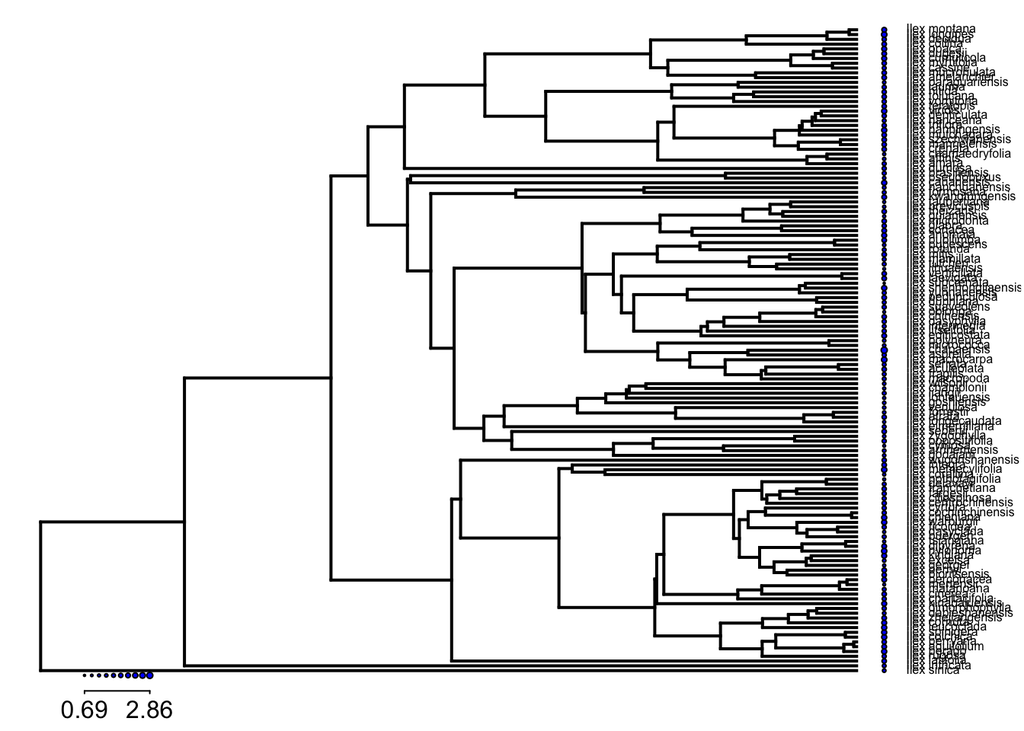

```r
VisualizeData_Discrete <- function(phy=phy, data=data) {
  dotTree(phy,data,length=10,fsize=0.5,lwd=2)
}
VisualizeData_Discrete(phy=clean.tree, data=clean.diameter)
```